# Introduction

This is a dataset on Airline On-Time Statistics and Delay Causes

The U.S. Department of Transportation's (DOT) Bureau of Transportation Statistics (BTS) tracks the on-time performance of domestic flights operated by large air carriers. Summary information on the number of on-time, delayed, canceled and diverted flights appears in DOT's monthly Air Travel Consumer Report, published about 30 days after the month's end, as well as in summary tables posted on this website. BTS began collecting details on the causes of flight delays in June 2003. Summary statistics and raw data are made available to the public at the time the Air Travel Consumer Report is released.

It includes 1493 entries. 16 domestic carriers. All these entries are in November 2020

Source: https://www.transtats.bts.gov/OT_Delay/OT_DelayCause1.asp

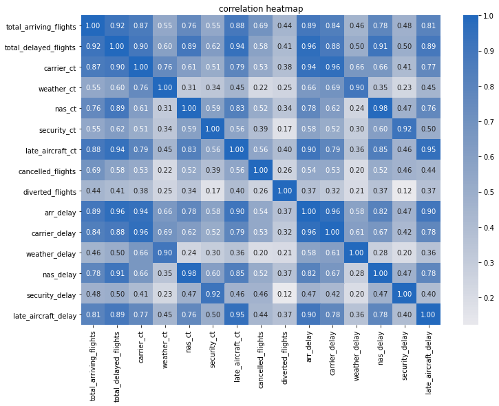

This heatmap highlights very interesting points that could be analysed even further. some of these points are:

- high correlation between `total delayed flights` and `total arriving flights`. this makes sesne since the more flights there are the higher the chnace of delay
- high correlation between `total delayed flights` and `carrier ct`. This could mean that a carrier could be the main culprit in delaying flights out of all the reasons?
- high correlation between `total delayed flights` and `late aircraft ct`. This could mean that the numner of times an aircraft is late plays a big factor in delaying flights.
- high correlation between `total delayed flights` and `arrival delay` in mins. This is pretty much self explanatory
- weak correlation between `number of diverted flights` and `security_ct`. Also makes sense since delay due to securoty reasons has no link to the the flight being diverted alltogether
- high correlation between `nas_delay` and `late_aircraft_ct`. I think `nas_delay` causes `late_aircraft_ct` and `late_aircraft_delay` -`nas_delay` is the cause for `arr_delay` since it is a subset of it -`nas_delay` is the cause for carrier delay `carrier_delay`?
- high correlation between `late_aircraft_delay` and `carrier_delay`. Is the sircraft late becuase of the carrier being late or is it the other way around?

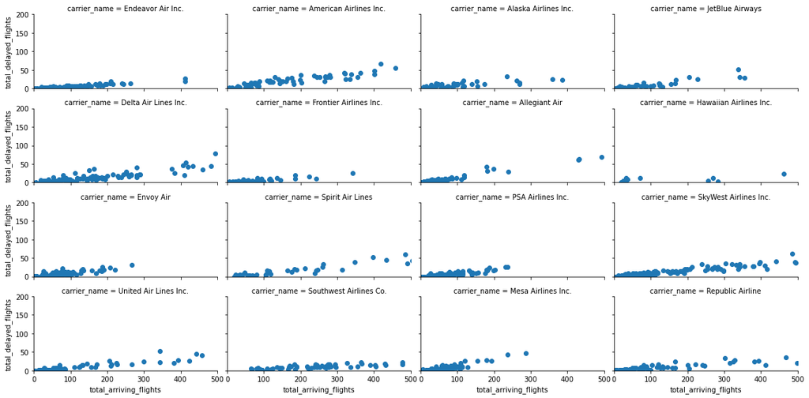

Seems like a large increase in number of arriving flights cause a slight increase in number of delayed flights

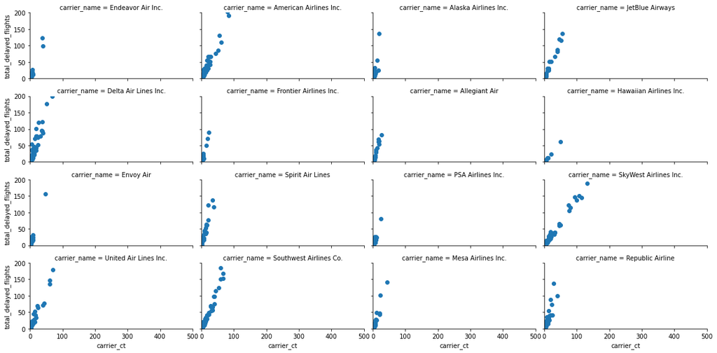

slight increase in carrier_ct causes a large increase in number of delayed flights. Makes sense!

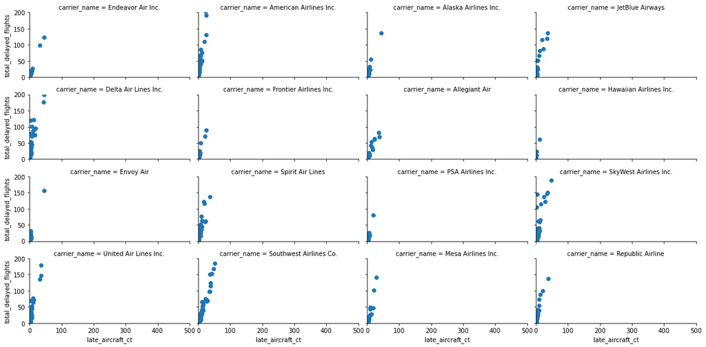

Again, a slight increase in late_aricraft_ct causes a large increase in number of delayed flights. Also Makes sense!

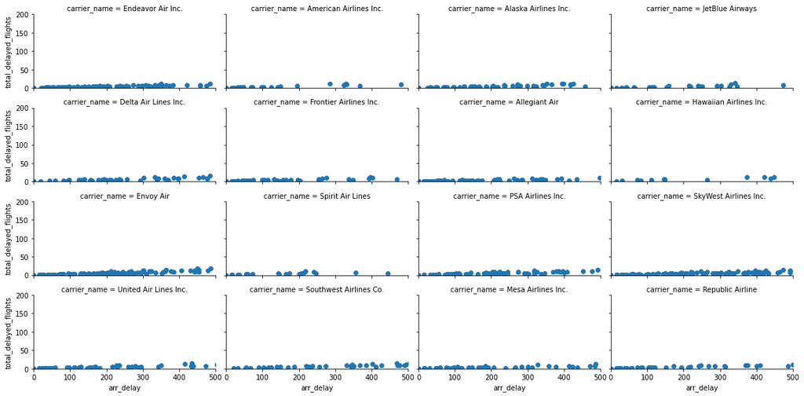

a slight increase in number of delayed flights causes a large increase in arrival delay time.

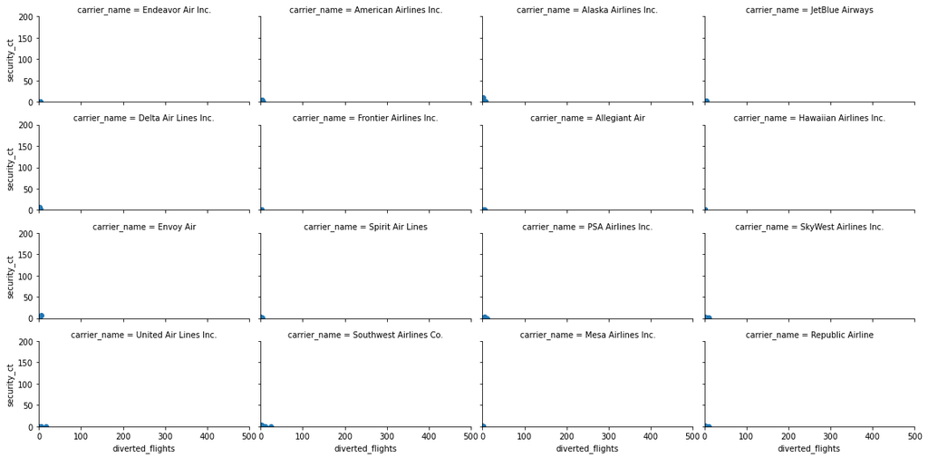

No relatioship whatsoever between security ct and number of diverted flights. Security ct is the number of flights delayed due to security reasons so it has nothing to do with number of diverted flights!

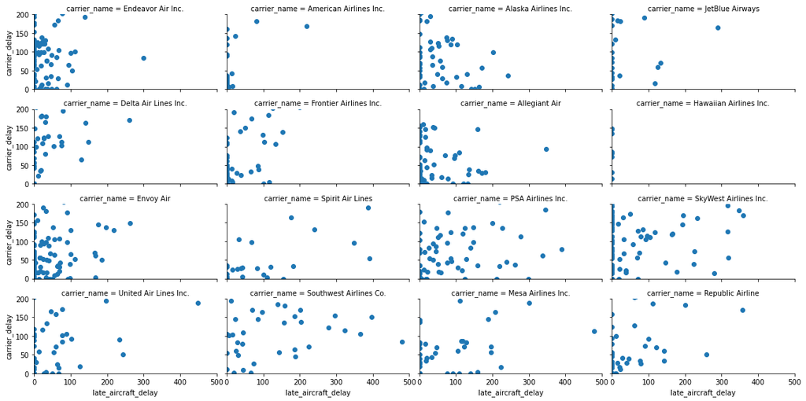

There is some sort of pattern here but i dont know how to explain it. The points are concentrated on the y axis for the most part for most carriers.

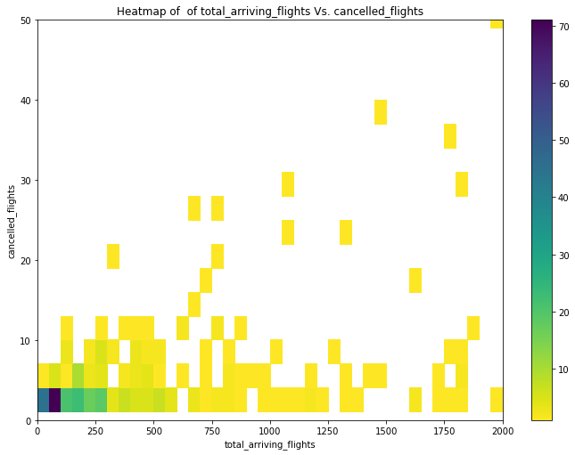

The darkest points are in the bottom left corner. However maybe a scatter plot could be more informative.

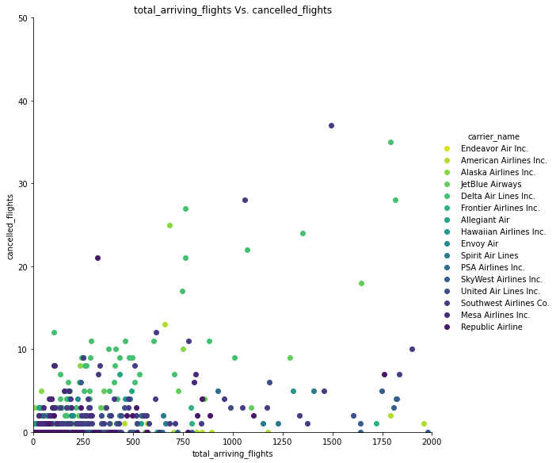

Most carriers are condensed on the bottom left corner with less arriving flights and a few cancelled flights. Some airlines however are up more to the right top corner and have a lot of arriving flights and therefore a higher number of cancelled flights

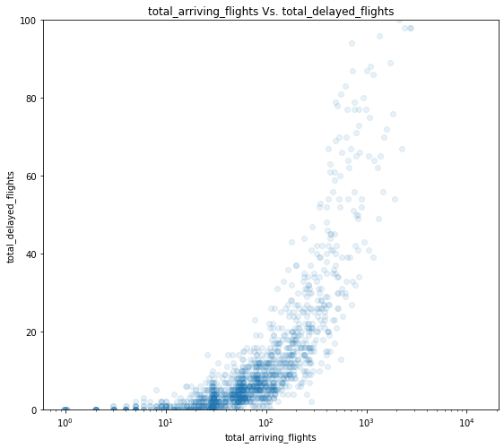

There seems to be an some kind of exponnetial relationship between `total_arriving_flights` and `total_delayed_flights`. After 100 total_arriving_flights the total_delayed_flights follow a very explosive increase. More arriving flights means more delayed flights which makes sense!

I hued the same graph with the carrier name.

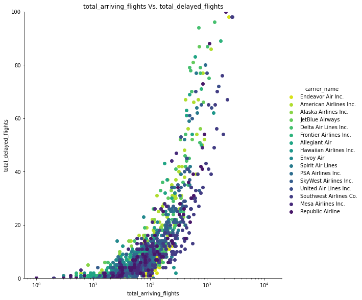

## Carrier name with the longest delay

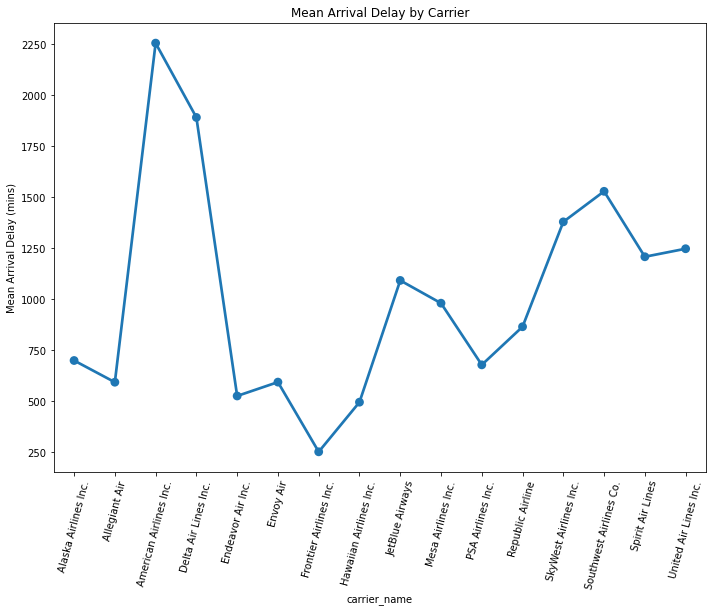

This point plot clearly shows that america airlines is the highest in mean arrival delay time while Frontier airlines is the lowest. However, a barplot could depict the order/ranking between them more clearly

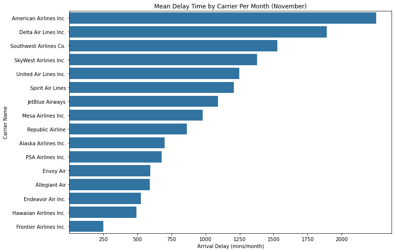

This plot shows clearly shows the order of mean delay time per month (November in this dataset) by carrier name. Top 3 most delayed airlines are:

- 'American Airlines Inc.'(highest)
- 'Delta Air Lines Inc.',
- 'Southwest Airlines Co.

least 3 delayed airlines are:

- 'Endeavor Air Inc.',
- 'Hawaiian Airlines Inc.',
- 'Frontier Airlines Inc. (lowest)

## Why is America Airlines the highest in mean arrival delay time?

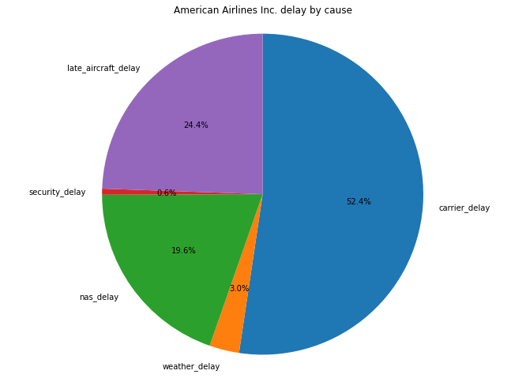

It is clear now that AA is highest in mean delay due to the carrier itself since 52.4% of its total delays in November 2020 is is due to carrier delay. Bad management maybe?

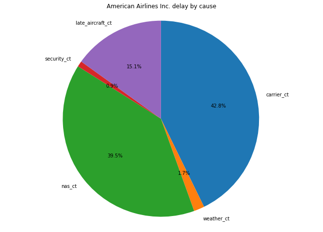

This pie chart also shows that not only is American Ailines highest in mean dealy time but the number of times its flights were delayed is mostly also because of them!

## What variable plays the biggest part in arrival delay?

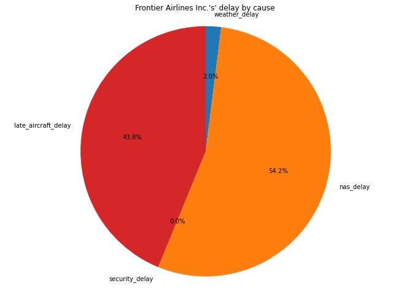

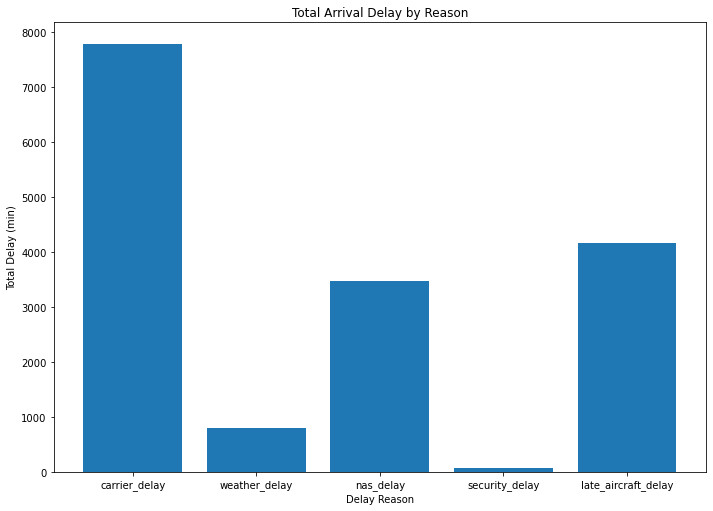

It is pretty clear now that carrier delay is the main culprit in arrival delay followed by late aircrafts

## What airline has the highest number of delayed flights?

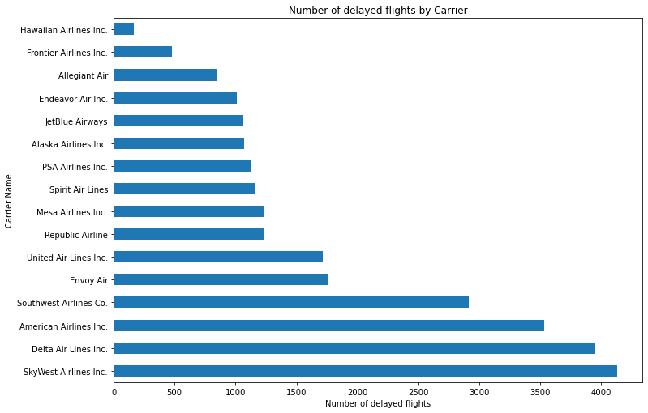

This is a pretty informative chart. However, we need to construct a ratio of delayed flights to arriving flights in order to be more accurate.

## Which airline is the most efficient (has least delays)?

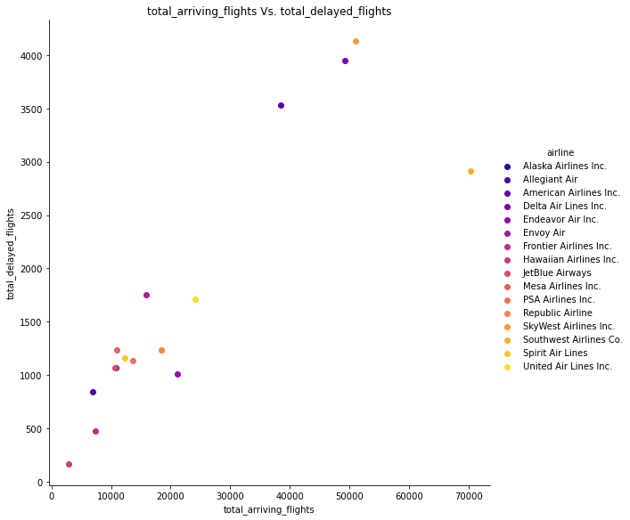

This scatter plot shows that 4 carriers are high up on total delayed flights and arriving flights while the rest are on the lower left corner. This is not enough. Let us use feature engineering to create ratio of delayed flights over total arriving flights and use that to acctually figure out what airlines are most and what airlines are least efficient.

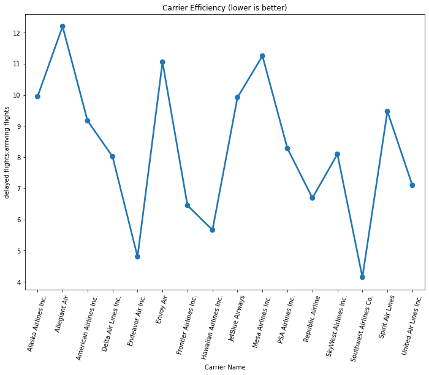

we can clearly see that `Southwest Airlines Co.` is the most efficient with the least delayed flights followed by `Endeavor Air Inc.` and `Hawaiian Airlines Inc.` and then `Frontier Airlines Inc.`